# act_report

## Report: act_report

## ANALYSIS AND VISUALIZATION

### We Rate Dogs Data.

WeRateDogs is a Twitter account that rates people's dogs with a humorous comment about the dog.

### Insights

#### Question 1: What is the most used twitter source?

The users make use of Twitter for iPhone, Twitter web client and TweetDeck. Twitter for iPhone is the most used by users with people on the platform tweets numbering over 1900 tweets while other clients didn’t even hit 50 tweets.

#### Question 2: Is there a cerrelation between favorite tweet count and retweet count?

A correlation coefficient of 0.7120771236948997 shows a positive correlation between favorite tweet count and retweeted tweet count. This is in order with normal behavior because if one favoritee a tweet, they are 70% more likely to also retweet that particular tweet.

#### Question 3; What is the highest favorite tweet count mean for the group dog stage?

The dog stage with the highest favorite count mean is Puppo. This implies that individuals were drawn to like images where the dog stage was Puppo with a mean of 12962.772727 followed by Doggo with a mean of 12546.698413.

#### Question 4: A Visualisation showing Retweets over Time

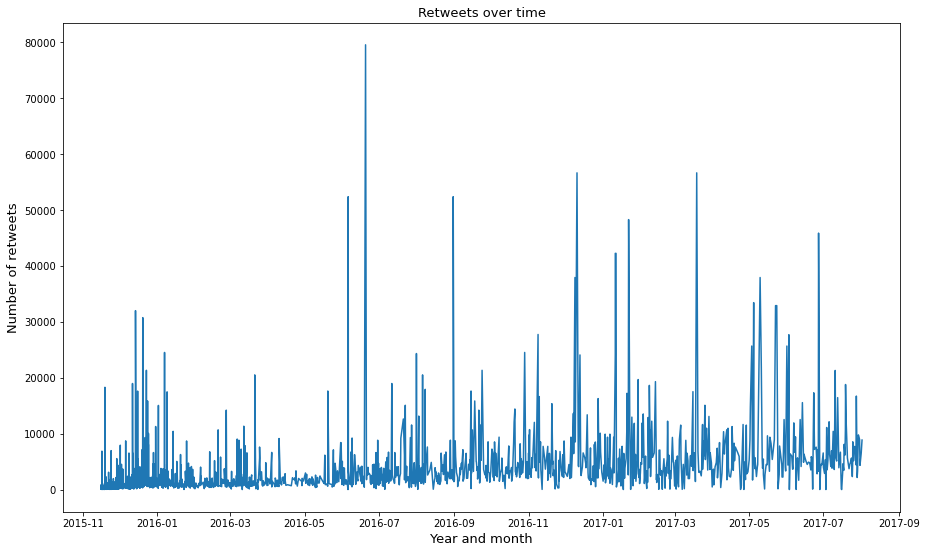